```python
%%javascript
IPython.OutputArea.prototype._should_scroll = function(lines) {
    return false;
}
```

# Post Goals

1. Discuss Confidence Interval for the difference between two means
2. Demonstrate how to test for significance for two unknown means and unknown standard deviations

# **Part 1:** Confidence Interval for the Difference between two means

- A confidence interval for the difference between two means specifies a range of values within which the difference between the means of the two populations may lie.
- In many cases, analyst, scientist, or researchers are interested in gather data for two populations in order to compare them.
- Confidence intervals and tests of significance are useful statistical tools to compare the difference between two population parameters.
- A confidence interval for the difference between two means will specify a range of values where the difference between the mean of the population exists.
- Examples:
- Company that wants to estimate the differnece in the mean number of downloads of a specific app.
- A researcher who wants to estimate the difference in efficacy between two Covid-19 vaccines in individuals that receivd them.

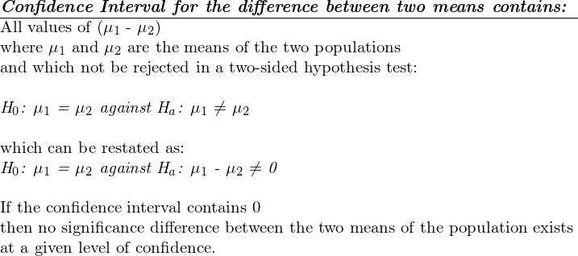

```python
# to load images for this tutorial
from IPython.display import Image
import os
path = os.getcwd()

meme = os.path.join(path, 'ci_means_info.png')
Image(filename=meme)
```

# **Part 2:** Demonstrate how to test for significance for two unknown means and unknown standard deviations

- Step 1: Calculate the two-sample t statistic
- Step 2: Calculate the confidence interval for the difference in means.

[figure not shown]

```python
# to load images for this tutorial
from IPython.display import Image
import os
path = os.getcwd()

meme = os.path.join(path, 'step1_tstatistic.png')
Image(filename=meme)
```

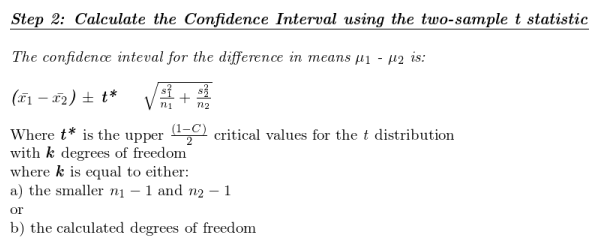

```python
# to load images for this tutorial
from IPython.display import Image
import os
path = os.getcwd()

meme = os.path.join(path, 'step2_ci_2means1.png')
Image(filename=meme)
```